# Sankey Diagram

Scott Haraburda

November 25, 2019

## Purpose.

To portray a graphical representation of the flow of entities (ie money, material, and labor) between nodes, such as processes and organizations. This uses codes to generate Sankey diagrams, which are visualizations used to depict a flow from one set of values to another in which the things being connected are called nodes and the connections are called links.

## Historical Example

[figure not shown]

*Figurative Map of the successive losses in men of the French Army in the Russian campain 1812-1813. Drawn up by M. Minard, Inspector General of Bridges and Roads in retirement. Paris, 20 November 1869. This work is in the public domain in its country of origin and other countries and areas where the copyright term is the author’s life plus 100 years.*

## Monetary Flow Example

The following example demonstrates how these diagrams can be used to visualize the relative flow of money from suppliers through the company to the customers. The following are snapshots of the nodes and links used in this code.

Nodes:

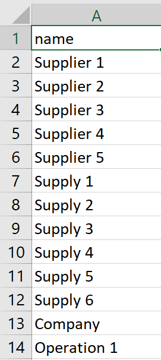

Links:

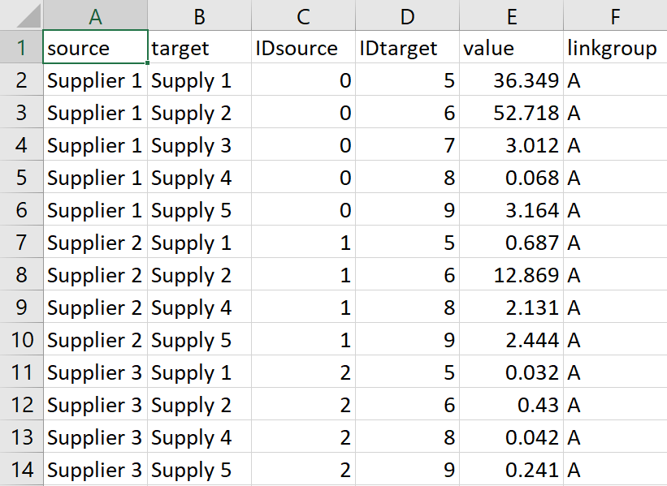

The following is the simple script for generating a Sankey diagram using the nodes and links files shown above. The monetary value of this was set to $k ($1,000).

```r
if (!require("pacman")) install.packages("pacman")
pacman::p_load(networkD3, tidyverse)
nodes<-read.csv("nodes.csv")
links<-read.csv("links.csv")
sankeyNetwork(Links = links, Nodes = nodes, Source = "IDsource",
    Target = "IDtarget", Value = "value", NodeID = "name",
    sinksRight=FALSE, fontSize = 12, units = "$k",
    LinkGroup = "linkgroup")
```

[interactive chart not shown]

The above interactive diagram shows the flow of money (or value of items) from five suppliers, through six supplies, to the company, used by two operations (and an additonal other), and finally to nine customers. The width of each connection (link) relates to the relative monetary value of the link. In this example, the biggest supplier is one (95k), the largest amount of supplies is two (69k), the largest operation is two (81k), and the biggest customer is eight (27k). The amounts in these parentheses can be seen on this diagram if you click the elongated rectangle to the left of the label, which makes this an interactive plot.

## Budget Example

The following example demonstrates how these diagrams can be used to visualize the relative flow of budget for multiple years through a company, broken down into budgetary groups. The following are snapshots of the nodes and links files that were used in this example.

Nodes:

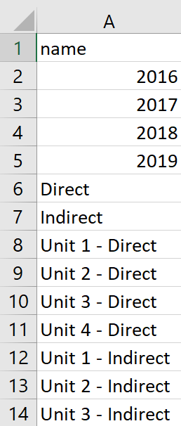

Links:

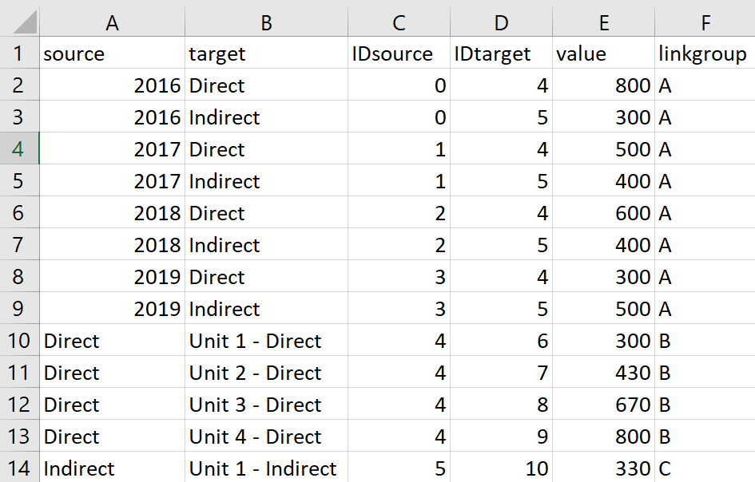

The following is the simple script for generating a Sankey diagram using the nodes and links files shown above. This script is the same as that from above, except it reads different nodes and links files.

```r
nodes<-read.csv("nodes2.csv")
links<-read.csv("links2.csv")
sankeyNetwork(Links = links, Nodes = nodes, Source = "IDsource",
    Target = "IDtarget", Value = "value", NodeID = "name",
    sinksRight=FALSE, fontSize = 12, units = "$k",
    LinkGroup = "linkgroup")
```

[interactive chart not shown]